# Result comparison

Chaeyoung Kim

2024-12-19

This R markdown the comparison of results of two data analysis.

```r
setwd("/Users/kimchaeyoung/Desktop/Applied_HT_analysis/Project/results/")
dir <- "/Users/kimchaeyoung/Desktop/Applied_HT_analysis/Project/results/"
```

```r
library(org.Hs.eg.db)
library(VennDiagram)
```

## Load in data

```r
results_files <- list.files(pattern = ".*.txt")
for (i in 1:length(results_files)) { #loop through .txt files, assign them to their respective variables
assign(sub("\\..*","",results_files[i]), read.table(results_files[i])) }
```

## 1. Fitration of RNA_seq results

This section filters the RNA-seq results based on an FDR threshold of 0.05, sorts the data by row names, and then performs an analysis based on CpG methylation data. A Venn diagram is created to visualize the overlap between the significant RNA-seq results and the CpG analysis.

```r
# RNAseq filtering
# Filtering RNAseq results with an FDR less than 0.05 and sorting the results by row names
RNAseq_filtered <- RNAseq_results[RNAseq_results$FDR < 0.05, ]
RNAseq_filtered <- RNAseq_filtered[order(rownames(RNAseq_filtered)), ]
ENS_RNA <- rownames(RNAseq_filtered[RNAseq_filtered$FDR<0.05,])
```

## 2.Comparison between RNA-seq analysis vs differentially methylated regions (DMRs)

- no overlappings

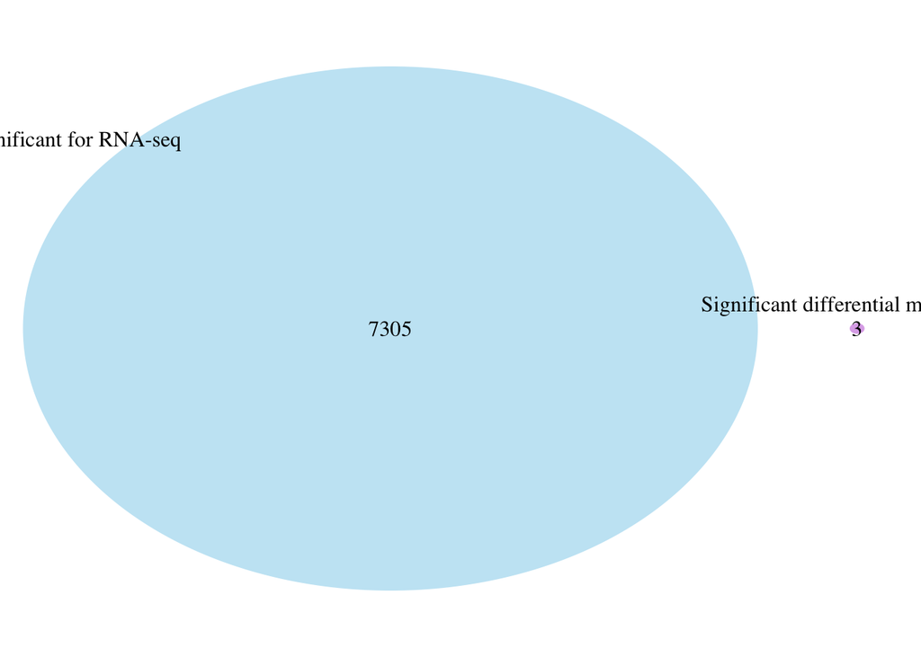

```
## (polygon[GRID.polygon.1], polygon[GRID.polygon.2], polygon[GRID.polygon.3], polygon[GRID.polygon.4], text[GRID.text.5], text[GRID.text.6], text[GRID.text.7], text[GRID.text.8])
```

```r
EntrezIDs_bmp <- read.table("EntrezIDs_bmp_results.txt", header = TRUE)

# Extracting the 'x' column as a vector
EntrezIDs_bmp_vec <- EntrezIDs_bmp$x
ENS_bmp <- mapIds(org.Hs.eg.db, as.character(EntrezIDs_bmp_vec), 'ENSEMBL', 'ENTREZID')
ENS_bmp_uniq <- ENS_bmp[!(duplicated(ENS_bmp) | is.na(ENS_bmp))]

# Create a Venn diagram to visualize the overlap between RNAseq results and DMRs
grid.newpage()
draw.pairwise.venn(
  area1 = length(rownames(RNAseq_filtered)),  # RNAseq filtered area
  area2 = length(ENS_bmp_uniq),               # CpG analysis area
  cross.area = length(intersect(rownames(RNAseq_filtered), ENS_bmp_uniq)),  # Intersection area
  category = c("Significant for RNA-seq", "Significant differential methylation (bumps) "),  # Category labels
  fill = c("skyblue", "mediumorchid"),
  lty = "blank"
)
```

## 3. Comparison betwen RNA-seq analysis and CpG based analysis

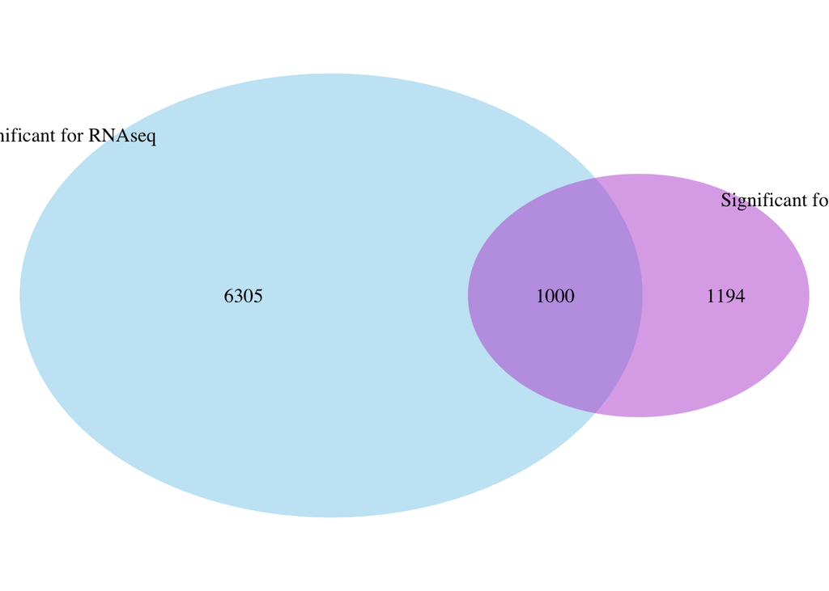

```
## (polygon[GRID.polygon.9], polygon[GRID.polygon.10], polygon[GRID.polygon.11], polygon[GRID.polygon.12], text[GRID.text.13], text[GRID.text.14], text[GRID.text.15], text[GRID.text.16], text[GRID.text.17])
```

```r
EntrezIDs_CpG <- read.table("EntrezIDs_CpG_results.txt", header = TRUE)

# Extracting the 'x' column as a vector
EntrezIDs_CpG_vec <- EntrezIDs_CpG$x
ENS_CpG <- mapIds(org.Hs.eg.db, as.character(EntrezIDs_CpG_vec), 'ENSEMBL', 'ENTREZID')
ENS_CpG_uniq <- ENS_CpG[!(duplicated(ENS_CpG) | is.na(ENS_CpG))]

# Create a Venn diagram to visualize the overlap between RNAseq results and CpG methylation results
grid.newpage()
draw.pairwise.venn(
  area1 = length(rownames(RNAseq_filtered)),  # RNAseq filtered area
  area2 = length(ENS_CpG_uniq),               # CpG analysis area
  cross.area = length(intersect(rownames(RNAseq_filtered), ENS_CpG_uniq)),  # Intersection area
  category = c("Significant for RNAseq", "Significant for CpG"),  # Category labels
  fill = c("skyblue", "mediumorchid"),
  lty = "blank"
)
```

## 4. Genes and Terms of interest

The diagram reveals that there are 26 GO terms that are shared by both RNA-seq and methylation analyses, which might represent biological processes or functions that are affected by both gene expression and DNA methylation

```r
print("Ensembl gene IDs that are significant:")
```

```
## [1] "Ensembl gene IDs that are significant:"
```

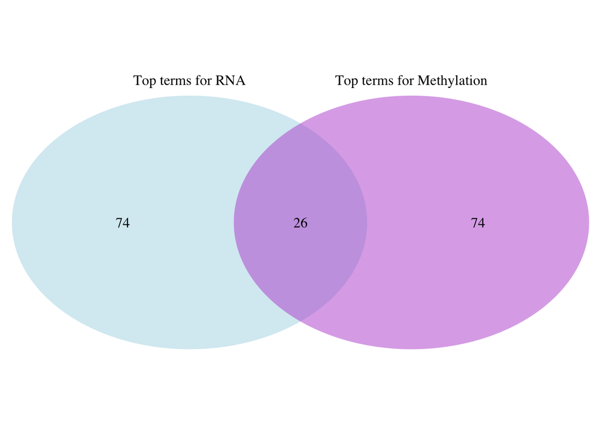

```
## (polygon[GRID.polygon.18], polygon[GRID.polygon.19], polygon[GRID.polygon.20], polygon[GRID.polygon.21], text[GRID.text.22], text[GRID.text.23], text[GRID.text.24], text[GRID.text.25], text[GRID.text.26])
```

```r
# Extract GO terms from RNA-seq analysis results
Metterms <- bmp_GSA_results$Term  # Extract GO terms related to RNA-seq

# Extract GO terms from methylation analysis results
RNAterms <- RNAseq_GSA_results$Term  # Extract GO terms related to methylation analysis

# Create a new graphics page for the Venn diagram
grid.newpage()
grid.newpage()
draw.pairwise.venn(length(RNAterms), length(Metterms), length(intersect(RNAterms,Metterms)), category = c("Top terms for RNA", "Top terms for Methylation"),
lty = rep("blank", 2), fill = c("light blue", "mediumorchid"), alpha = rep(0.5, 2), cat.pos = c(0, 0), cat.dist = rep(0.025, 2))
```

## 5. Ensembl gene IDs that are significant for the two analyses (RNAseq and CpG)

This section finds the common genes between RNA-seq and CpG methylation analysis.

```r
# Find common genes between RNAseq results and CpG analysis
print("Ensembl gene IDs that are significant for the two analyses:")
```

```
## [1] "Ensembl gene IDs that are significant for the two analyses:"
```

```r
common_genes <- intersect(ENS_RNA, ENS_CpG)  # Identify genes that are significant in both RNAseq and CpG analyses\
head(common_genes)
```

```
## [1] "ENSG00000001460" "ENSG00000001617" "ENSG00000001629" "ENSG00000002746"
## [5] "ENSG00000002822" "ENSG00000003147"
```

```r
# Top GO terms overlapping for the two analyses
print("Top overlapping GO terms:")
```

```
## [1] "Top overlapping GO terms:"
```

```r
common_terms <- intersect(RNAterms, Metterms)  # Identify common GO terms between RNAseq and methylation analysis
head(common_terms)
```

```
## [1] "cellular component organization or biogenesis"
## [2] "cellular component organization"
## [3] "cellular process"
## [4] "positive regulation of biological process"
## [5] "positive regulation of cellular process"
## [6] "organelle organization"
```

```r
# Genes of interest (GOI) based on the common genes found in RNAseq and CpG
# Extract genes of interest from RNAseq results based on the common genes.

GOI <- RNAseq_results[which(rownames(RNAseq_results) %in% common_genes), ]
rownames(GOI) <- mapIds(org.Hs.eg.db, rownames(GOI), 'SYMBOL', 'ENSEMBL')  # Convert ENSEMBL IDs to SYMBOLs
# Terms of interest (POI) based on the common GO terms
# Extract terms of interest based on the common GO terms.
POI <- RNAseq_GSA_results[which(RNAseq_GSA_results$Term %in% common_terms), ]

# View top 10 rows of both GOI and POI
# Display the top 10 genes and GO terms of interest.
```

### 5.1. GOI

In this analysis, positive logFC values indicate up-regulated genes, meaning these genes have increased expression in the experimental condition compared to the control. Genes like CFLAR, KDM1A, and RBM6 are examples of up-regulated genes. On the other hand, negative logFC values indicate down-regulated genes, meaning these genes have decreased expression in the experimental condition. Examples of down-regulated genes include STPG1, SEMA3F, ANKIB1, HECW1, MAD1L1, and ICA1, which all show reduced expression. Therefore, genes with positive logFC values are up-regulated, while genes with negative logFC values are down-regulated in the experimental group.

```r
head(GOI, n=10)
```

```
##             ensembl_id gene_name     logFC    logCPM        F       PValue
## STPG1  ENSG00000127928     GNGT1 -8.060504 1.9722937 201.4226 9.670295e-09
## SEMA3F ENSG00000060718   COL11A1 -8.703936 5.7733561 216.5736 4.633264e-08
## ANKIB1 ENSG00000228742 LINC02577 -5.249074 1.6900926 120.7926 5.485484e-08
## HECW1  ENSG00000095203  EPB41L4B -2.977733 4.0113937 188.9327 1.070544e-07
## MAD1L1 ENSG00000223485 LINC01615 -4.594110 0.1554300  86.6495 1.114826e-07
## ICA1   ENSG00000214336     FOXI3 -5.372894 0.6769829 129.1362 1.431481e-07
## CFLAR  ENSG00000116983    HPCAL4  3.527323 2.3264447 177.2282 1.553250e-07
## MTMR7  ENSG00000119547   ONECUT2 -3.808518 0.9149784 132.8048 1.764565e-07
## KDM1A  ENSG00000197256     KANK2  1.914136 7.4096116 163.7816 2.069153e-07
## RBM6   ENSG00000076555     ACACB  2.451443 5.8016488 163.0520 2.112539e-07
##                 FDR
## STPG1  2.351332e-05
## SEMA3F 8.046987e-05
## ANKIB1 8.336221e-05
## HECW1  8.606043e-05
## MAD1L1 8.606043e-05
## ICA1   8.606043e-05
## CFLAR  8.606043e-05
## MTMR7  8.606043e-05
## KDM1A  8.606043e-05
## RBM6   8.606043e-05
```

### 5.2. POI

The terms with higher DE values indicate biological processes that are most impacted by the experimental conditions. For example, the “cellular process” term (GO:0009987) is associated with 6561 DE genes, meaning that a significant portion of the genes in this category show altered expression.

```r
head(POI, n=10)
```

```
##                                                     Term Ont     N   DE
## GO:0071840 cellular component organization or biogenesis  BP  6791 3055
## GO:0016043               cellular component organization  BP  6581 2953
## GO:0009987                              cellular process  BP 17647 6561
## GO:0048518     positive regulation of biological process  BP  6411 2801
## GO:0048522       positive regulation of cellular process  BP  5861 2575
## GO:0006996                        organelle organization  BP  3623 1696
## GO:0032502                         developmental process  BP  6593 2813
## GO:0007275            multicellular organism development  BP  4764 2126
## GO:0048856              anatomical structure development  BP  6016 2587
## GO:0051128 regulation of cellular component organization  BP  2459 1198
##                     P.DE       FDR.DE
## GO:0071840 1.260280e-101 2.369432e-98
## GO:0016043  6.361506e-95 1.104015e-91
## GO:0009987  1.545568e-72 1.660456e-69
## GO:0048518  7.704438e-72 7.900901e-69
## GO:0048522  9.664818e-67 8.721919e-64
## GO:0006996  2.854111e-61 2.012237e-58
## GO:0032502  3.844905e-59 2.344457e-56
## GO:0007275  2.087326e-58 1.239267e-55
## GO:0048856  2.623950e-56 1.345430e-53
## GO:0051128  3.758547e-52 1.630704e-49
```